# Country Level Zero Inflation Fits

Necessary files:

```r
#read the file, if you dont have it from the previous markdown.
aei <- read.csv("/Volumes/RachelExternal/Thesis/Data_upload_for_CL/AEI.csv")
```

# Eight Region Model

Jumping in to the zero inflated models. Some helpful stuff here has been [*How to analyze visual analog (slider) scale data?*](https://mvuorre.github.io/posts/2019-02-18-analyze-analog-scale-ratings-with-zero-one-inflated-beta-models/) by Matti Vuorre Vuorre (2019).

## The Model

Following what he has done, specify a `bf()`. Here we are using regions as the grouping factor, just to get things going. I’ve specified no priors here. Getting things running is the goal here. There is no time series component here, ignoring this for now.

```r
#specifying the brms formula
zi_eight_regions_bf <-
  bf(
  irrfrac ~ eight_regions,
  phi ~ eight_regions,
  zi ~ eight_regions,
  family = zero_inflated_beta()
)
```

```r
#and the model
zi_eight_regions <-
  brm(
  formula = zi_eight_regions_bf,
  data = aei,
  cores = 4,
  seed = 17,
  file = "/Volumes/RachelExternal/Thesis/Thesis/fits/CL_Zero_Inflated_Fits/zero_inflated_eight_regions"
)
```

```r
print(zi_eight_regions)
```

```
##  Family: zero_inflated_beta
##   Links: mu = logit; phi = log; zi = logit
## Formula: irrfrac ~ eight_regions
##          phi ~ eight_regions
##          zi ~ eight_regions
##    Data: aei (Number of observations: 1688)
## Samples: 4 chains, each with iter = 2000; warmup = 1000; thin = 1;
##          total post-warmup samples = 4000
##
## Population-Level Effects:
##                                     Estimate Est.Error l-95% CI u-95% CI Rhat
## Intercept                              -4.27      0.18    -4.64    -3.91 1.01
## phi_Intercept                           3.78      0.24     3.28     4.23 1.01
## zi_Intercept                          -39.78     33.10  -126.01    -5.09 1.01
## eight_regionsafrica_sub_saharan        -0.60      0.20    -1.00    -0.19 1.01
## eight_regionsamerica_north              0.41      0.20     0.01     0.82 1.01
## eight_regionsamerica_south             -0.61      0.21    -1.01    -0.19 1.01
## eight_regionsasia_west                  1.40      0.20     1.00     1.80 1.01
## eight_regionseast_asia_pacific          1.03      0.21     0.63     1.46 1.01
## eight_regionseurope_east                1.05      0.21     0.63     1.47 1.01
## eight_regionseurope_west                1.11      0.21     0.70     1.54 1.01
## phi_eight_regionsafrica_sub_saharan     0.07      0.26    -0.44     0.60 1.01
## phi_eight_regionsamerica_north         -0.15      0.27    -0.67     0.40 1.01
## phi_eight_regionsamerica_south          1.00      0.29     0.43     1.57 1.01
## phi_eight_regionsasia_west             -1.13      0.27    -1.63    -0.60 1.01
## phi_eight_regionseast_asia_pacific     -1.05      0.28    -1.59    -0.51 1.01
## phi_eight_regionseurope_east           -1.24      0.27    -1.79    -0.70 1.01
## phi_eight_regionseurope_west           -1.04      0.28    -1.59    -0.49 1.01
## zi_eight_regionsafrica_sub_saharan     37.06     33.10     2.36   123.36 1.01
## zi_eight_regionsamerica_north          38.52     33.10     3.78   124.89 1.01
## zi_eight_regionsamerica_south          18.34     37.28   -44.05   111.72 1.00
## zi_eight_regionsasia_west              36.72     33.11     2.04   123.17 1.01
## zi_eight_regionseast_asia_pacific      39.42     33.10     4.76   125.71 1.01
## zi_eight_regionseurope_east            24.58     34.68   -20.62   116.01 1.01
## zi_eight_regionseurope_west            39.04     33.11     4.39   125.14 1.01
##                                     Bulk_ESS Tail_ESS
## Intercept                                317      456
## phi_Intercept                            374      758
## zi_Intercept                             325      370
## eight_regionsafrica_sub_saharan          353      556
```

[output cut: 9 more lines]

```
## phi_eight_regionsasia_west               410     1065
## phi_eight_regionseast_asia_pacific       429     1028
## phi_eight_regionseurope_east             420     1038
## phi_eight_regionseurope_west             438     1073
## zi_eight_regionsafrica_sub_saharan       325      375
## zi_eight_regionsamerica_north            326      370
## zi_eight_regionsamerica_south            329      350
## zi_eight_regionsasia_west                325      375
## zi_eight_regionseast_asia_pacific        326      369
## zi_eight_regionseurope_east              343      383
## zi_eight_regionseurope_west              326      370
##
## Samples were drawn using sampling(NUTS). For each parameter, Bulk_ESS
## and Tail_ESS are effective sample size measures, and Rhat is the potential
## scale reduction factor on split chains (at convergence, Rhat = 1).
```

This took about an hour to run. But rhats converged.

## Priors

```r
prior_summary(zi_eight_regions)
```

```
##                 prior     class                            coef group resp dpar
##                (flat)         b
##                (flat)         b eight_regionsafrica_sub_saharan
##                (flat)         b      eight_regionsamerica_north
##                (flat)         b      eight_regionsamerica_south
##                (flat)         b          eight_regionsasia_west
##                (flat)         b  eight_regionseast_asia_pacific
##                (flat)         b        eight_regionseurope_east
##                (flat)         b        eight_regionseurope_west
##                (flat)         b                                             phi
##                (flat)         b eight_regionsafrica_sub_saharan             phi
##                (flat)         b      eight_regionsamerica_north             phi
##                (flat)         b      eight_regionsamerica_south             phi
##                (flat)         b          eight_regionsasia_west             phi
##                (flat)         b  eight_regionseast_asia_pacific             phi
##                (flat)         b        eight_regionseurope_east             phi
##                (flat)         b        eight_regionseurope_west             phi
##                (flat)         b                                              zi
##                (flat)         b eight_regionsafrica_sub_saharan              zi
##                (flat)         b      eight_regionsamerica_north              zi
##                (flat)         b      eight_regionsamerica_south              zi
##                (flat)         b          eight_regionsasia_west              zi
##                (flat)         b  eight_regionseast_asia_pacific              zi
##                (flat)         b        eight_regionseurope_east              zi
##                (flat)         b        eight_regionseurope_west              zi
##  student_t(3, 0, 2.5) Intercept
##  student_t(3, 0, 2.5) Intercept                                             phi
##        logistic(0, 1) Intercept                                              zi
##  nlpar bound       source
##                   default
##              (vectorized)
##              (vectorized)
##              (vectorized)
##              (vectorized)
##              (vectorized)
##              (vectorized)
##              (vectorized)
##              (vectorized)
##              (vectorized)
##              (vectorized)
##              (vectorized)
##              (vectorized)
##              (vectorized)
##              (vectorized)
##              (vectorized)
##              (vectorized)
##              (vectorized)
##              (vectorized)
##              (vectorized)
##              (vectorized)
##              (vectorized)
##              (vectorized)
##              (vectorized)
##                   default
##                   default
##                   default
```

Does `get_prior()` give me something different here?

```r
get_prior(zi_eight_regions_bf, aei, family = zero_inflated_beta())
```

```
##                 prior     class                            coef group resp dpar
##                (flat)         b
##                (flat)         b eight_regionsafrica_sub_saharan
##                (flat)         b      eight_regionsamerica_north
##                (flat)         b      eight_regionsamerica_south
##                (flat)         b          eight_regionsasia_west
##                (flat)         b  eight_regionseast_asia_pacific
##                (flat)         b        eight_regionseurope_east
##                (flat)         b        eight_regionseurope_west
##  student_t(3, 0, 2.5) Intercept
##                (flat)         b                                             phi
##                (flat)         b eight_regionsafrica_sub_saharan             phi
##                (flat)         b      eight_regionsamerica_north             phi
##                (flat)         b      eight_regionsamerica_south             phi
##                (flat)         b          eight_regionsasia_west             phi
##                (flat)         b  eight_regionseast_asia_pacific             phi
##                (flat)         b        eight_regionseurope_east             phi
##                (flat)         b        eight_regionseurope_west             phi
##  student_t(3, 0, 2.5) Intercept                                             phi
##                (flat)         b                                              zi
##                (flat)         b eight_regionsafrica_sub_saharan              zi
##                (flat)         b      eight_regionsamerica_north              zi
##                (flat)         b      eight_regionsamerica_south              zi
##                (flat)         b          eight_regionsasia_west              zi
##                (flat)         b  eight_regionseast_asia_pacific              zi
##                (flat)         b        eight_regionseurope_east              zi
##                (flat)         b        eight_regionseurope_west              zi
##        logistic(0, 1) Intercept                                              zi
##  nlpar bound       source
##                   default
##              (vectorized)
##              (vectorized)
##              (vectorized)
##              (vectorized)
##              (vectorized)
##              (vectorized)
##              (vectorized)
##                   default
##              (vectorized)
##              (vectorized)
##              (vectorized)
##              (vectorized)
##              (vectorized)
##              (vectorized)
##              (vectorized)
##              (vectorized)
##                   default
##              (vectorized)
##              (vectorized)
##              (vectorized)
##              (vectorized)
##              (vectorized)
##              (vectorized)
##              (vectorized)
##              (vectorized)
##                   default
```

Nah, exactly the same thing.

### Visualization of b coeff Prior - Uniform

Alright, weve got flat priors for all of the b coeffs, a student t for the intercept (and phi’s intercept), and a logistic prior for zi. We can do better than flat priors, the student t probably doesn’t do too poor of a job. lets see if we can visualize some of these.

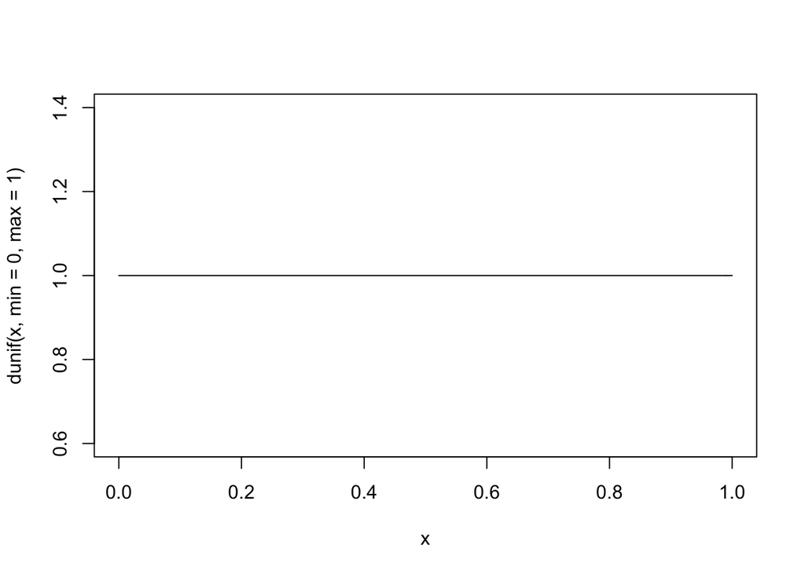

```r
x <- seq(0,1,0.01)
curve(dunif(x, min = 0, max = 1))
```

Hahaha, Art. Yeah, so this is what is influencing the b_ coeffs, which is pretty much everything in the fit. We’ve got a decent amount of data with this model formula so this shouldnt have any influence on the estimates.

### Visualization of Overall Intercept and Phi Prior - Student T

For the overall intercept and the phi? The students t using the specified degrees of freedom in the prior.

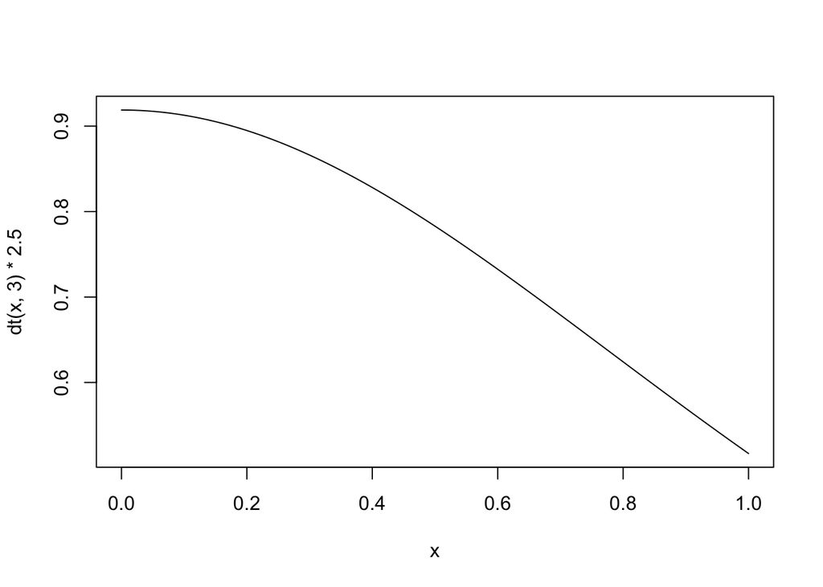

```r
curve(dt(x, 3)*2.5) # a scaled student t
```

Alright this one doesn’t look too too bad, considering we are very zero inflated, it does capture the general structure of our data which would be fine since this is the default prior for the intercept. But as the probability increases, this prior is probably a bit too generous (weak). I am still unsure how this prior would behave for the phi paramater.

### Visualization of Overall Zi Prior - Logarithmic

Finally the logarithmic prior for the zi paramater.

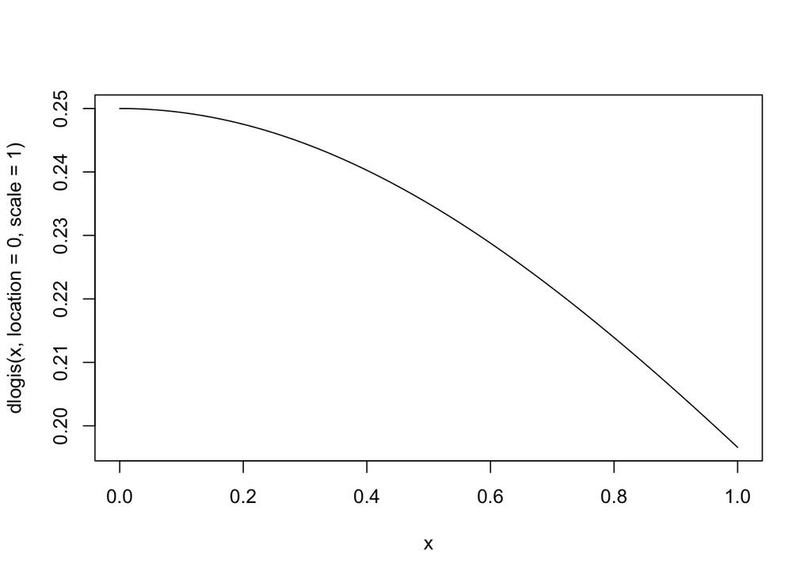

```r
curve(dlogis(x, location = 0, scale = 1))
```

Ok, a similar thing is captured here as for the student t. This prior is weakly informing the model that the probability of 0s in our data set is closer to 0 than it is to 1, which seems a fair assumtion here.

We can probably do better than this, both interms of the priors and the brms formula specified. But lets check out the posterior, that has been transfromed.

## Posterior

### Untransformed Densities for Post Estimates

Ok, so here are some of the posterior estimates for the predictors, they are still in the logit and log scale so the distrobutions are not representative of the propbability scale.

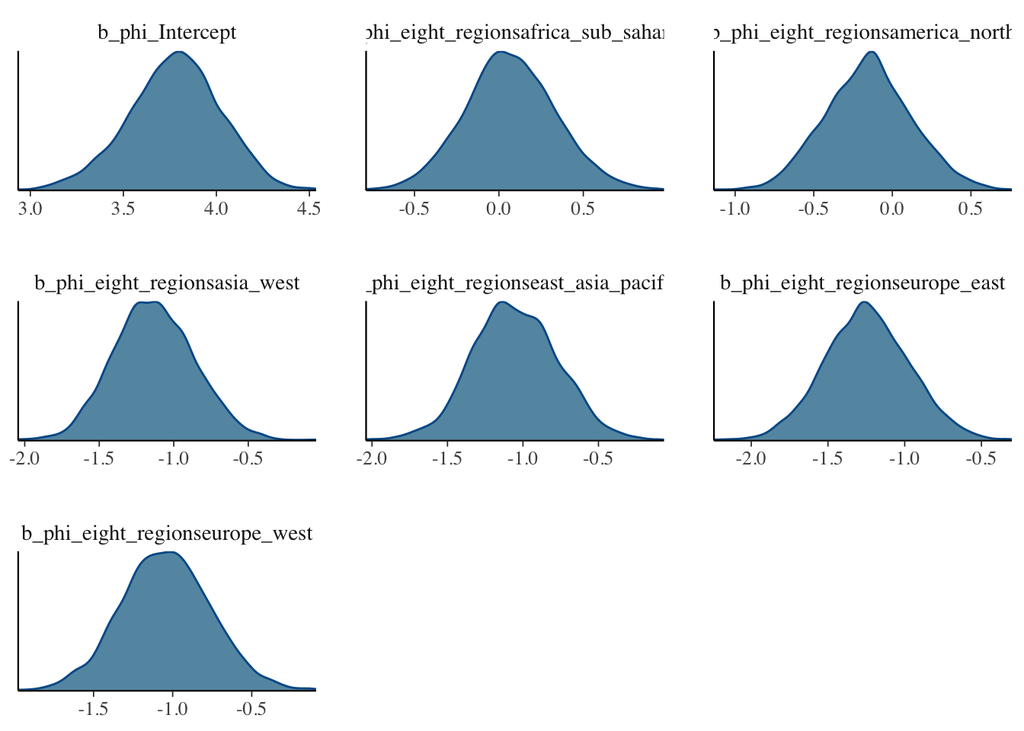

```r
mcmc_plot(zi_eight_regions, pars = c("b_phi_Intercept",
                        "b_phi_eight_regionsafrica_sub_saharan",
                        "b_phi_eight_regionsamerica_north",
                        "b_phi_eight_regionsasia_west",
                        "b_phi_eight_regionseast_asia_pacific",
                        "b_phi_eight_regionseurope_east",
                        "b_phi_eight_regionseurope_west"),
          type = "dens")
```

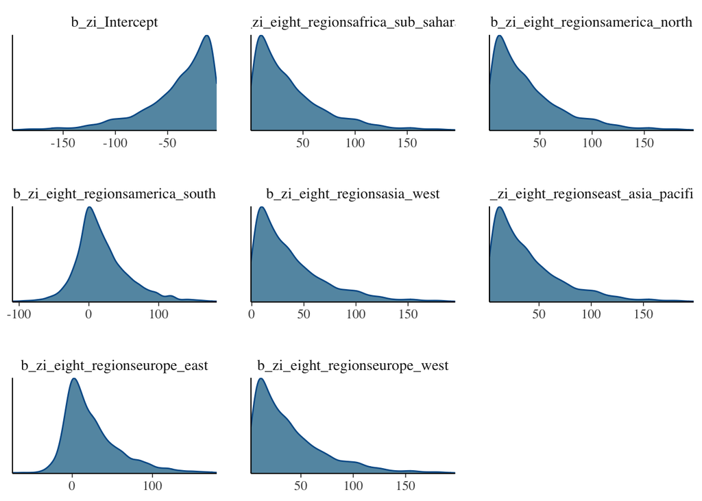

```r
mcmc_plot(zi_eight_regions, pars = "b_zi_", type = "dens")
```

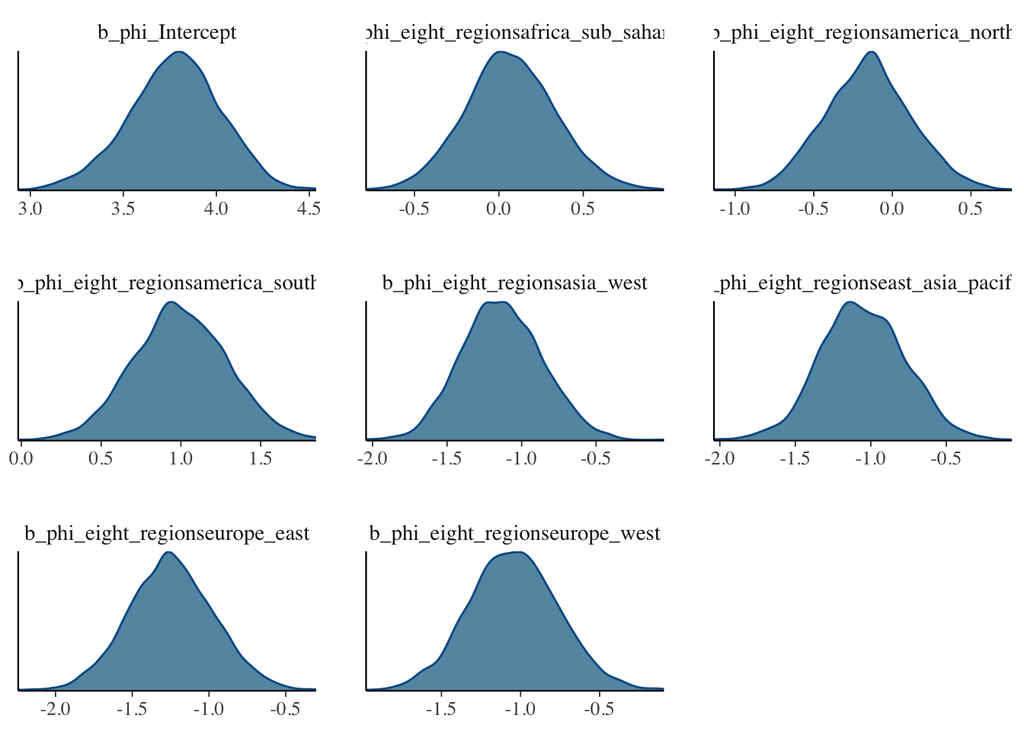

```r
mcmc_plot(zi_eight_regions, pars = "b_phi_", type = "dens")
```

Alright. Need to work out a bit of what is being communicated here. Majority of these plots seem similarly wide. Some of the Zi paramaters seem bounded by zero on either the top or the bottom end. Perhaps I am having a hard time with these because I have not transformed them in to the response scale. Let’s do that now.

### Transformed Posterior

All of the summary output is transformed via the logit ($\mu, zi$) or log ($\phi$) link. We need to transform them in to the response scale, use `exp` to transform $\phi$ and `plogis` for $\mu$ and $zi$ to be able to interpret them better. I am assuming that all parameters that are $\phi$ related have the same log link and need to be transformed via `exp` and others need`plogis` as they use the logit link. Is this a fair assumption?

```r
posterior_samples(zi_eight_regions, pars = "b_")[,1:24] %>%
  #the old fashioned way, brute force.
  mutate_at(c("b_phi_Intercept", "b_phi_eight_regionsafrica_sub_saharan",
              "b_phi_eight_regionsamerica_north",
              "b_phi_eight_regionsamerica_north",
              "b_phi_eight_regionsasia_west",
              "b_phi_eight_regionseast_asia_pacific",
              "b_phi_eight_regionseurope_east",
              "b_phi_eight_regionseurope_west"), exp) %>%
  mutate_at(vars(-c("b_phi_Intercept", "b_phi_eight_regionsafrica_sub_saharan",
              "b_phi_eight_regionsamerica_north",
              "b_phi_eight_regionsamerica_north",
              "b_phi_eight_regionsasia_west",
              "b_phi_eight_regionseast_asia_pacific",
              "b_phi_eight_regionseurope_east",
              "b_phi_eight_regionseurope_west")), plogis) %>%
  posterior_summary() %>%
  as.data.frame() %>%
  rownames_to_column("Parameter") %>%
  kable(digits = 2)
```

| Parameter | Estimate | Est.Error | Q2.5 | Q97.5 |
| --- | --- | --- | --- | --- |
| b_Intercept | 0.01 | 0.00 | 0.01 | 0.02 |
| b_phi_Intercept | 44.95 | 10.90 | 26.46 | 68.84 |
| b_zi_Intercept | 0.00 | 0.00 | 0.00 | 0.01 |
| b_eight_regionsafrica_sub_saharan | 0.36 | 0.05 | 0.27 | 0.45 |
| b_eight_regionsamerica_north | 0.60 | 0.05 | 0.50 | 0.69 |
| b_eight_regionsamerica_south | 0.35 | 0.05 | 0.27 | 0.45 |
| b_eight_regionsasia_west | 0.80 | 0.03 | 0.73 | 0.86 |
| b_eight_regionseast_asia_pacific | 0.74 | 0.04 | 0.65 | 0.81 |
| b_eight_regionseurope_east | 0.74 | 0.04 | 0.65 | 0.81 |
| b_eight_regionseurope_west | 0.75 | 0.04 | 0.67 | 0.82 |
| b_phi_eight_regionsafrica_sub_saharan | 1.11 | 0.30 | 0.65 | 1.82 |
| b_phi_eight_regionsamerica_north | 0.89 | 0.25 | 0.51 | 1.49 |
| b_phi_eight_regionsamerica_south | 0.73 | 0.06 | 0.61 | 0.83 |
| b_phi_eight_regionsasia_west | 0.33 | 0.09 | 0.20 | 0.55 |
| b_phi_eight_regionseast_asia_pacific | 0.36 | 0.10 | 0.20 | 0.60 |
| b_phi_eight_regionseurope_east | 0.30 | 0.08 | 0.17 | 0.50 |
| b_phi_eight_regionseurope_west | 0.37 | 0.11 | 0.20 | 0.61 |
| b_zi_eight_regionsafrica_sub_saharan | 0.99 | 0.03 | 0.91 | 1.00 |
| b_zi_eight_regionsamerica_north | 1.00 | 0.01 | 0.98 | 1.00 |
| b_zi_eight_regionsamerica_south | 0.67 | 0.45 | 0.00 | 1.00 |
| b_zi_eight_regionsasia_west | 0.99 | 0.05 | 0.88 | 1.00 |
| b_zi_eight_regionseast_asia_pacific | 1.00 | 0.00 | 0.99 | 1.00 |
| b_zi_eight_regionseurope_east | 0.76 | 0.40 | 0.00 | 1.00 |
| b_zi_eight_regionseurope_west | 1.00 | 0.01 | 0.99 | 1.00 |

Alright, so this has been transformed back in to the response scale. Some things are still a bit confusing to me here. One region (north africa) is encapsulated by the population level Intercept, zi_intercept, and phi_intercept. The phi_intercept is huge here, 44.95, but is similar to others as the difference between the intercept and the groups is captured by the specific “b_phi” value.

Here “b_zi” is a measure of the proportions of zeros present in the data set, as it is just a bernoulli distrobution? Is this correct? and How could it be that for europe west and east asia pacific that the probability of a country having an irrigation value of 0 is 1? Is this a correct interpretation?

### Conditional Effects

We can also check out the conditional effects for this, they are also automatically transformed to the response scale, yay for brms!

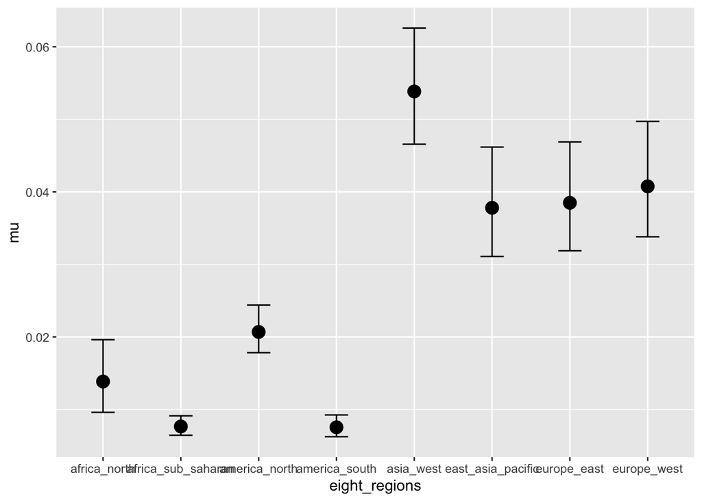

```r
conditional_effects(zi_eight_regions, dpar = "mu")
```

Ok so this is the spread of mu, the average for the response, of irrigated land per country. Remember this is represented from 0 to 1. These don’t seem to be too off in a conceptual sense. Sub-saharan Africa and south America have lower rates of irrigation than northern africa (its dry?) and north america (its big). Highest rates of irrigation are found in west asia, which also makes a sense, as these areas are usually fertile and dry, hence the need for irrigation. Then europe, east and west, along with east asia have expectedly high rates of irrigation.

Some things to remember here though: each of these groups have a different number of countries that conclusions are being based off. (Ignore the NAs, they have zero irrigation fraction as per the Siebert Data).

```r
aei %>%
  group_by(eight_regions) %>%
  count()
```

```
## # A tibble: 9 x 2
## # Groups:   eight_regions [9]
##   eight_regions          n
##   <chr>              <int>
## 1 africa_north          48
## 2 africa_sub_saharan   384
## 3 america_north        256
## 4 america_south        104
## 5 asia_west            216
## 6 east_asia_pacific    280
## 7 europe_east          184
## 8 europe_west          216
## 9 <NA>                 160
```

### Posterior Predictive Check

quick posterior check!

```r
pp_check(zi_eight_regions)
```

```
## Using 10 posterior samples for ppc type 'dens_overlay' by default.
```

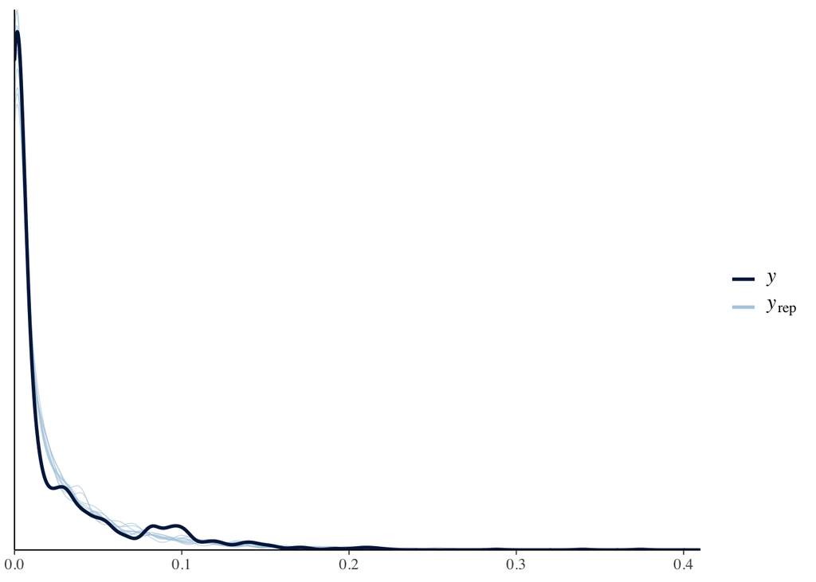

ahh this makes me so happy, as it looks so much better than the gaussian models I had been messing around with earlier.

# Simple Model with Sensible Predictors

Ok, let’s try something here that is a bit more sensible in terms of predictors. Lets keep things linear with no hierarchial structure and try to set up some priors if we can.

## The Model

```r
zi_simple_preds_1_bf <-
  bf(
  irrfrac ~ yearcount,
  phi ~ yearcount,
  zi ~ yearcount + area_km,
  family = zero_inflated_beta()
)
```

Ok so here we assume that the irrigation fraction depends on the year, the dispersion coeff ($\phi$) is dependent on the year as well, and that the probability of a 0 is a linear function of the year and the size of the country. All are continuous.

```r
#and the model
zi_simple_preds_1 <-
  brm(
  formula = zi_simple_preds_1_bf,
  data = aei,
  cores = 4,
  seed = 17,
  file = "/Volumes/RachelExternal/Thesis/Thesis/fits/CL_Zero_Inflated_Fits/zi_simple_preds_1"
)
```

```r
print(zi_simple_preds_1)
```

```
##  Family: zero_inflated_beta
##   Links: mu = logit; phi = log; zi = logit
## Formula: irrfrac ~ yearcount
##          phi ~ yearcount
##          zi ~ yearcount + area_km
##    Data: aei (Number of observations: 1688)
## Samples: 4 chains, each with iter = 2000; warmup = 1000; thin = 1;
##          total post-warmup samples = 4000
##
## Population-Level Effects:
##               Estimate Est.Error l-95% CI u-95% CI Rhat Bulk_ESS Tail_ESS
## Intercept       -22.15     15.20   -37.64    -5.54 4.34        4       11
## phi_Intercept     4.55      5.81    -8.98    11.58 3.68        4       11
## zi_Intercept      3.18     33.08   -30.95    49.44 3.64        4       11
## yearcount         0.86      0.63     0.16     1.53 4.49        4       11
## phi_yearcount    -0.18      0.22    -0.44     0.32 3.48        4       11
## zi_yearcount     -0.04      1.28    -1.83     1.26 4.36        4       11
## zi_area_km       -0.00      0.00    -0.00    -0.00 2.45        5       30
##
## Samples were drawn using sampling(NUTS). For each parameter, Bulk_ESS
## and Tail_ESS are effective sample size measures, and Rhat is the potential
## scale reduction factor on split chains (at convergence, Rhat = 1).
```

Hmm.. This did not go the way that I expected at all, and I cant really use the output here as the Rhats have not converged to 1 and my effective sample sizes are laughable.

## The Even Simpler Simple Model

Ok, so divergent transitions are through the roof. Lets knock out the $\phi$ parameter, cause I wanna model something I understand at this point. haha.

```r
zi_simple_preds_2_bf <-
  bf(
  irrfrac ~ yearcount,
  zi ~ yearcount,
  family = zero_inflated_beta()
)
```

```r
#and the model
zi_simple_preds_2 <-
  brm(
  formula = zi_simple_preds_2_bf,
  data = aei,
  cores = 4,
  seed = 17,
  file = "/Volumes/RachelExternal/Thesis/Thesis/fits/CL_Zero_Inflated_Fits/zi_simple_preds_2"
)
```

No yelling about divergent transitions here, I would be mad if it had.

```r
print(zi_simple_preds_2)
```

```
##  Family: zero_inflated_beta
##   Links: mu = logit; phi = identity; zi = logit
## Formula: irrfrac ~ yearcount
##          zi ~ yearcount
##    Data: aei (Number of observations: 1688)
## Samples: 4 chains, each with iter = 2000; warmup = 1000; thin = 1;
##          total post-warmup samples = 4000
##
## Population-Level Effects:
##              Estimate Est.Error l-95% CI u-95% CI Rhat Bulk_ESS Tail_ESS
## Intercept       -3.76      0.06    -3.89    -3.64 1.00     2921     2906
## zi_Intercept    -1.26      0.13    -1.51    -1.02 1.00     3116     2510
## yearcount        0.01      0.00     0.00     0.01 1.00     5487     3031
## zi_yearcount    -0.02      0.00    -0.02    -0.01 1.00     3777     2956
##
## Family Specific Parameters:
##     Estimate Est.Error l-95% CI u-95% CI Rhat Bulk_ESS Tail_ESS
## phi    16.52      0.79    14.99    18.07 1.00     1964     2054
##
## Samples were drawn using sampling(NUTS). For each parameter, Bulk_ESS
## and Tail_ESS are effective sample size measures, and Rhat is the potential
## scale reduction factor on split chains (at convergence, Rhat = 1).
```

```r
zi_simple_preds_3_bf <-
  bf(
  irrfrac ~ yearcount,
  zi ~ yearcount,
  family = zero_inflated_beta()
)
```

```r
#and the model
zi_simple_preds_3 <-
  brm(
  formula = zi_simple_preds_3_bf,
  data = aei,
  cores = 4,
  seed = 17,
  file = "/Volumes/RachelExternal/Thesis/Thesis/fits/CL_Zero_Inflated_Fits/zi_simple_preds_3"
)
```

```r
print(zi_simple_preds_3)
```

```
##  Family: zero_inflated_beta
##   Links: mu = logit; phi = identity; zi = logit
## Formula: irrfrac ~ yearcount
##          zi ~ yearcount
##    Data: aei (Number of observations: 1688)
## Samples: 4 chains, each with iter = 2000; warmup = 1000; thin = 1;
##          total post-warmup samples = 4000
##
## Population-Level Effects:
##              Estimate Est.Error l-95% CI u-95% CI Rhat Bulk_ESS Tail_ESS
## Intercept       -3.76      0.06    -3.89    -3.64 1.00     2921     2906
## zi_Intercept    -1.26      0.13    -1.51    -1.02 1.00     3116     2510
## yearcount        0.01      0.00     0.00     0.01 1.00     5487     3031
## zi_yearcount    -0.02      0.00    -0.02    -0.01 1.00     3777     2956
##
## Family Specific Parameters:
##     Estimate Est.Error l-95% CI u-95% CI Rhat Bulk_ESS Tail_ESS
## phi    16.52      0.79    14.99    18.07 1.00     1964     2054
##
## Samples were drawn using sampling(NUTS). For each parameter, Bulk_ESS
## and Tail_ESS are effective sample size measures, and Rhat is the potential
## scale reduction factor on split chains (at convergence, Rhat = 1).
```

```r
zi_simple_preds_4_bf <-
  bf(
  irrfrac ~ yearcount,
  zi ~ area_km_std,
  family = zero_inflated_beta()
)
```

```r
#and the model
zi_simple_preds_4 <-
  brm(
  formula = zi_simple_preds_4_bf,
  data = aei,
  cores = 4,
  seed = 17,
  file = "/Volumes/RachelExternal/Thesis/Thesis/fits/CL_Zero_Inflated_Fits/zi_simple_preds_4"
)
```

```r
print(zi_simple_preds_4)
```

```
##  Family: zero_inflated_beta
##   Links: mu = logit; phi = identity; zi = logit
## Formula: irrfrac ~ yearcount
##          zi ~ area_km_std
##    Data: aei (Number of observations: 1688)
## Samples: 4 chains, each with iter = 2000; warmup = 1000; thin = 1;
##          total post-warmup samples = 4000
##
## Population-Level Effects:
##                Estimate Est.Error l-95% CI u-95% CI Rhat Bulk_ESS Tail_ESS
## Intercept         -3.76      0.06    -3.88    -3.64 1.00     2313     2656
## zi_Intercept      -0.88      0.08    -1.04    -0.71 1.00     2715     3158
## yearcount          0.01      0.00     0.00     0.01 1.00     4765     2560
## zi_area_km_std    -3.35      0.40    -4.18    -2.58 1.01     1212     1367
##
## Family Specific Parameters:
##     Estimate Est.Error l-95% CI u-95% CI Rhat Bulk_ESS Tail_ESS
## phi    16.52      0.78    14.99    18.08 1.00     1405     1639
##
## Samples were drawn using sampling(NUTS). For each parameter, Bulk_ESS
## and Tail_ESS are effective sample size measures, and Rhat is the potential
## scale reduction factor on split chains (at convergence, Rhat = 1).
```

## Alright, Lets Get Down to Business

Ok, lets think about this seriously and see if I can take something from this.

```r
zi_mod_1_bf <-
  bf(
    irrfrac ~ yearcount + log_pop_std + log_income_std + rugged_sc,
    phi ~ 1,
    zi ~ area_km_std,
    family = zero_inflated_beta()
  )

get_prior(zi_mod_1_bf, data = aei)
```

```
##                 prior     class           coef group resp dpar nlpar bound
##                (flat)         b
##                (flat)         b log_income_std
##                (flat)         b    log_pop_std
##                (flat)         b      rugged_sc
##                (flat)         b      yearcount
##  student_t(3, 0, 2.5) Intercept
##  student_t(3, 0, 2.5) Intercept                            phi
##                (flat)         b                             zi
##                (flat)         b    area_km_std              zi
##        logistic(0, 1) Intercept                             zi
##        source
##       default
##  (vectorized)
##  (vectorized)
##  (vectorized)
##  (vectorized)
##       default
##       default
##  (vectorized)
##  (vectorized)
##       default
```

```r
zi_mod_1 <-
  brm(
  formula = zi_mod_1_bf,
  data = aei,
  cores = 4,
  seed = 17,
  file = "/Volumes/RachelExternal/Thesis/Thesis/fits/CL_Zero_Inflated_Fits/zi_mods_1"
)
```

```r
print(zi_mod_1)
```

```
##  Family: zero_inflated_beta
##   Links: mu = logit; phi = log; zi = logit
## Formula: irrfrac ~ yearcount + log_pop_std + log_income_std + rugged_sc
##          phi ~ 1
##          zi ~ area_km_std
##    Data: aei (Number of observations: 1440)
## Samples: 4 chains, each with iter = 2000; warmup = 1000; thin = 1;
##          total post-warmup samples = 4000
##
## Population-Level Effects:
##                Estimate Est.Error l-95% CI u-95% CI Rhat Bulk_ESS Tail_ESS
## Intercept         -8.26      0.31    -8.86    -7.65 1.00     2417     2806
## phi_Intercept      3.03      0.05     2.93     3.13 1.00     2353     2462
## zi_Intercept      -0.97      0.10    -1.18    -0.77 1.00     2874     2711
## yearcount          0.00      0.00     0.00     0.01 1.00     6911     2689
## log_pop_std        3.02      0.23     2.56     3.47 1.00     2698     2912
## log_income_std     1.07      0.17     0.73     1.40 1.00     3021     2437
## rugged_sc          1.62      0.14     1.35     1.88 1.00     2781     2760
## zi_area_km_std    -5.09      0.68    -6.50    -3.83 1.00     1838     1863
##
## Samples were drawn using sampling(NUTS). For each parameter, Bulk_ESS
## and Tail_ESS are effective sample size measures, and Rhat is the potential
## scale reduction factor on split chains (at convergence, Rhat = 1).
```

```r
zi_mod_2_bf <-
  bf(
    irrfrac ~ yearcount + log_pop_std + log_income_std + rugged_sc,
    zi ~ area_km_std,
    family = zero_inflated_beta()
  )
```

```r
zi_mod_2 <-
  brm(
  formula = zi_mod_2_bf,
  data = aei,
  cores = 4,
  seed = 17,
  file = "/Volumes/RachelExternal/Thesis/Thesis/fits/CL_Zero_Inflated_Fits/zi_mods_2"
)
```

```r
print(zi_mod_2)
```

```
##  Family: zero_inflated_beta
##   Links: mu = logit; phi = identity; zi = logit
## Formula: irrfrac ~ yearcount + log_pop_std + log_income_std + rugged_sc
##          zi ~ area_km_std
##    Data: aei (Number of observations: 1440)
## Samples: 4 chains, each with iter = 2000; warmup = 1000; thin = 1;
##          total post-warmup samples = 4000
##
## Population-Level Effects:
##                Estimate Est.Error l-95% CI u-95% CI Rhat Bulk_ESS Tail_ESS
## Intercept         -8.27      0.31    -8.88    -7.64 1.00     2503     2616
## zi_Intercept      -0.97      0.10    -1.16    -0.78 1.00     3014     2910
## yearcount          0.00      0.00     0.00     0.01 1.00     6532     3129
## log_pop_std        3.02      0.23     2.56     3.47 1.00     2668     2395
## log_income_std     1.08      0.17     0.75     1.41 1.00     2768     2375
## rugged_sc          1.63      0.14     1.35     1.90 1.00     2682     2704
## zi_area_km_std    -5.09      0.67    -6.45    -3.87 1.00     1904     2062
##
## Family Specific Parameters:
##     Estimate Est.Error l-95% CI u-95% CI Rhat Bulk_ESS Tail_ESS
## phi    20.74      1.05    18.74    22.83 1.00     2205     2535
##
## Samples were drawn using sampling(NUTS). For each parameter, Bulk_ESS
## and Tail_ESS are effective sample size measures, and Rhat is the potential
## scale reduction factor on split chains (at convergence, Rhat = 1).
```

## The Posterior

```r
posterior_samples(zi_mod_1, pars = "b_")[,1:8] %>%
  #the old fashioned way, brute force.
  mutate_at(c("b_phi_Intercept"), exp) %>%
  mutate_at(vars(-c("b_phi_Intercept")), plogis) %>%
  posterior_summary() %>%
  as.data.frame() %>%
  rownames_to_column("Parameter") %>%
  kable(digits = 2)
```

| Parameter | Estimate | Est.Error | Q2.5 | Q97.5 |
| --- | --- | --- | --- | --- |
| b_Intercept | 0.00 | 0.00 | 0.00 | 0.00 |
| b_phi_Intercept | 20.66 | 1.06 | 18.64 | 22.83 |
| b_zi_Intercept | 0.28 | 0.02 | 0.24 | 0.32 |
| b_yearcount | 0.50 | 0.00 | 0.50 | 0.50 |
| b_log_pop_std | 0.95 | 0.01 | 0.93 | 0.97 |
| b_log_income_std | 0.74 | 0.03 | 0.68 | 0.80 |
| b_rugged_sc | 0.83 | 0.02 | 0.79 | 0.87 |
| b_zi_area_km_std | 0.01 | 0.01 | 0.00 | 0.02 |

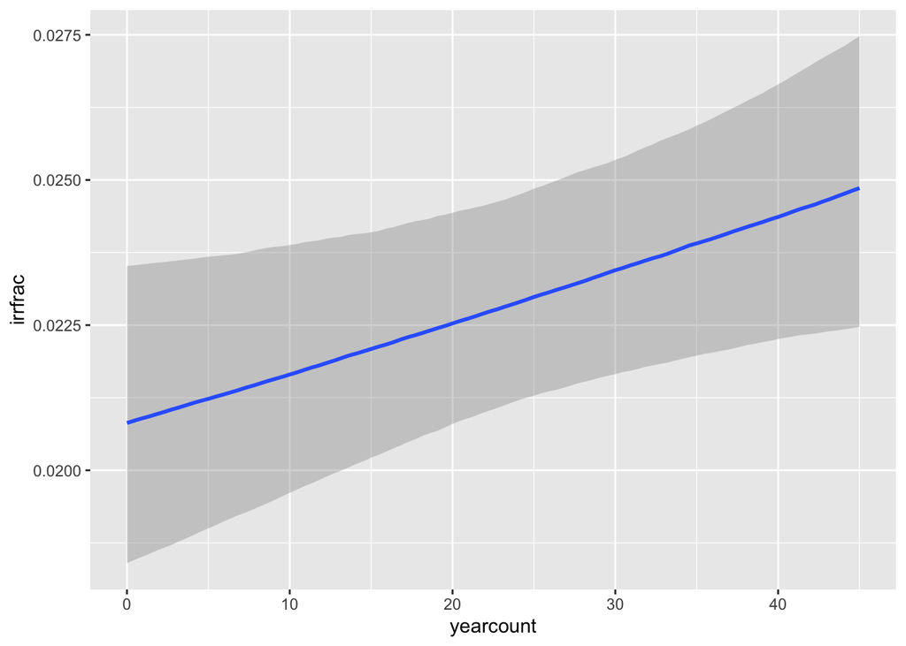

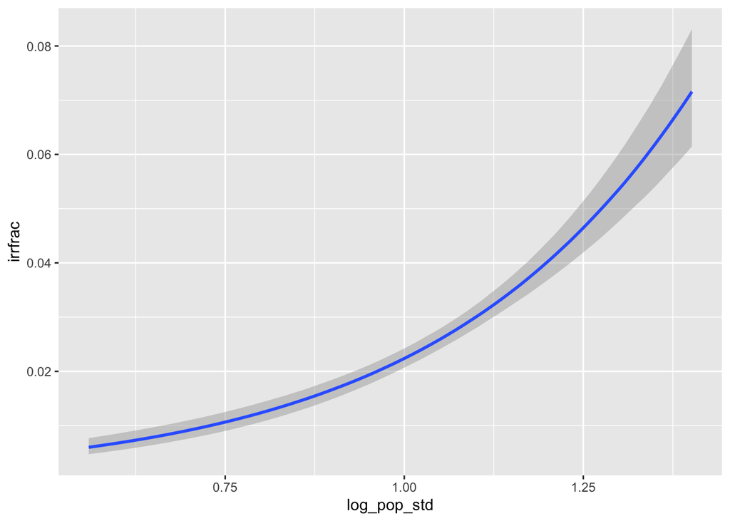

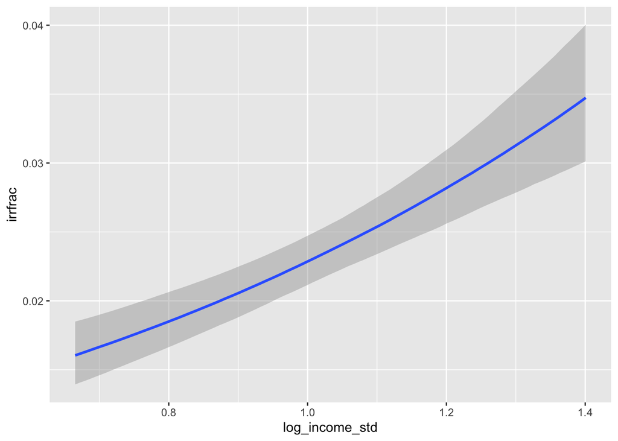

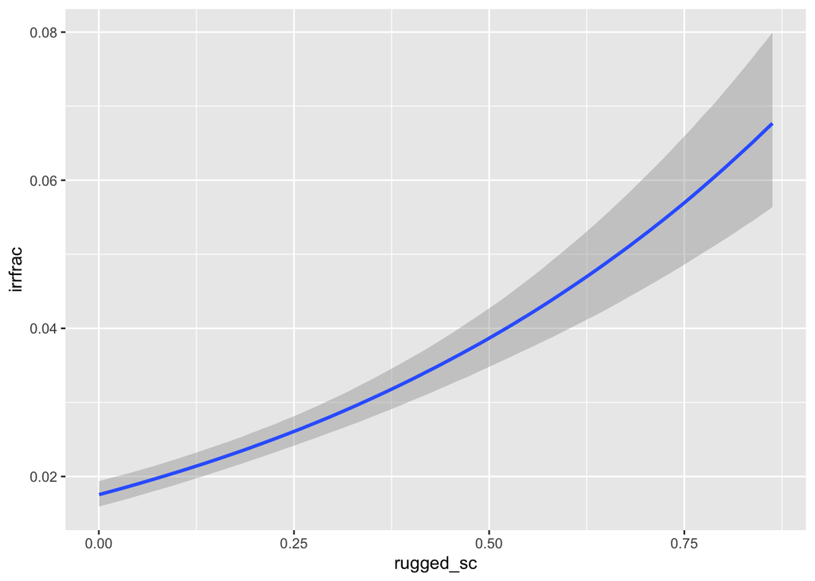

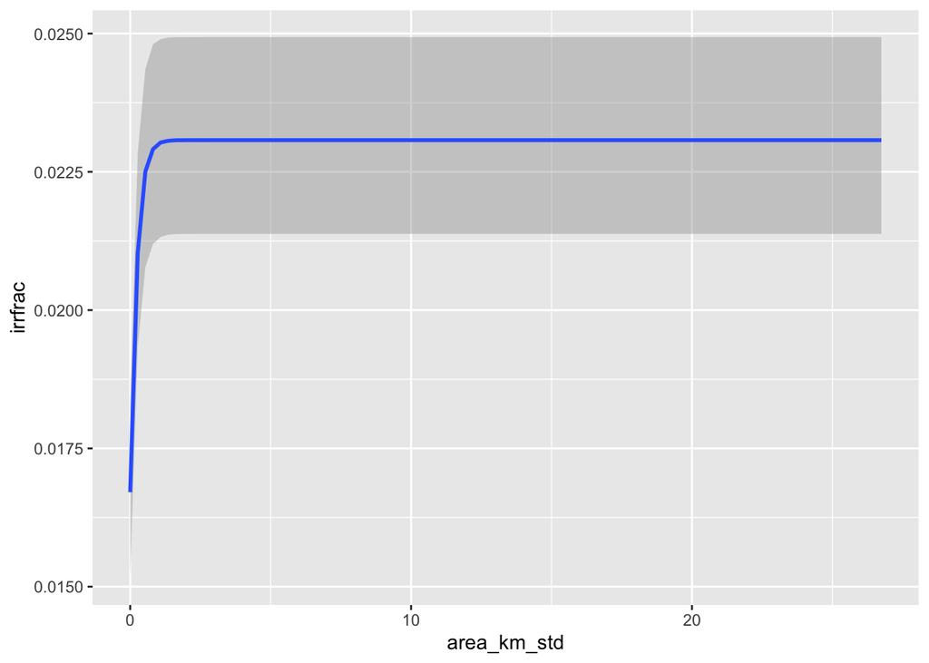

```r
conditional_effects(zi_mod_1)
```

```r
posterior_samples(zi_mod_2)[,1:8] %>%
  #the old fashioned way, brute force.
  mutate_at(c("phi"), exp) %>%
  mutate_at(vars(-c("phi")), plogis) %>%
  posterior_summary() %>%
  as.data.frame() %>%
  rownames_to_column("Parameter") %>%
  kable(digits = 5)
```

| Parameter | Estimate | Est.Error | Q2.5 | Q97.5 |
| --- | --- | --- | --- | --- |
| b_Intercept | 2.700000e-04 | 9.000000e-05 | 1.400000e-04 | 4.800000e-04 |
| b_zi_Intercept | 2.752200e-01 | 1.994000e-02 | 2.382200e-01 | 3.151100e-01 |
| b_yearcount | 5.010100e-01 | 4.500000e-04 | 5.001400e-01 | 5.018900e-01 |
| b_log_pop_std | 9.525700e-01 | 1.069000e-02 | 9.282300e-01 | 9.699200e-01 |
| b_log_income_std | 7.448700e-01 | 3.222000e-02 | 6.785500e-01 | 8.036100e-01 |
| b_rugged_sc | 8.352700e-01 | 1.924000e-02 | 7.943100e-01 | 8.701800e-01 |
| b_zi_area_km_std | 7.570000e-03 | 5.110000e-03 | 1.570000e-03 | 2.046000e-02 |
| phi | 1.751209e+09 | 2.315357e+09 | 1.381425e+08 | 8.223483e+09 |

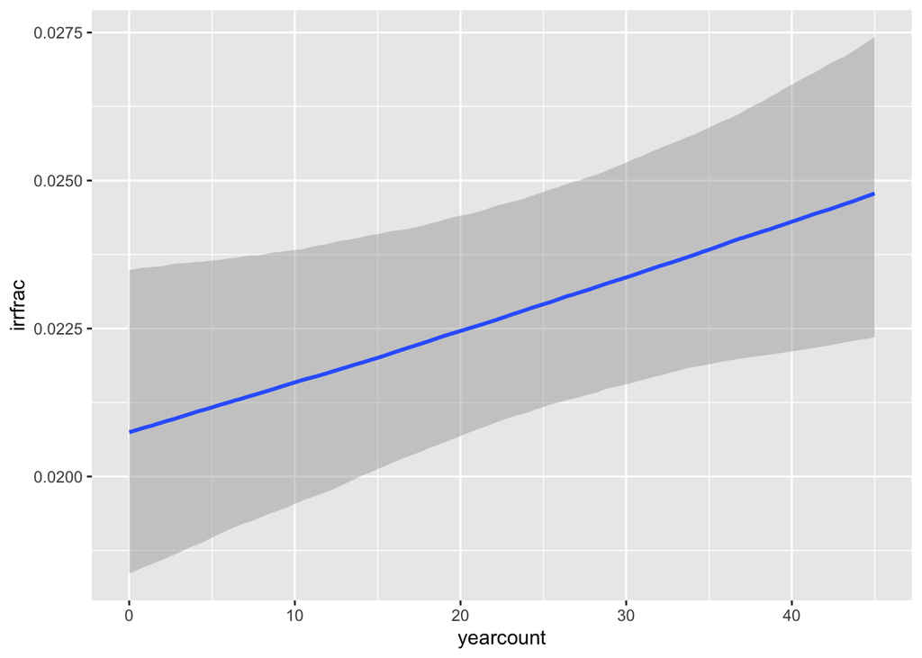

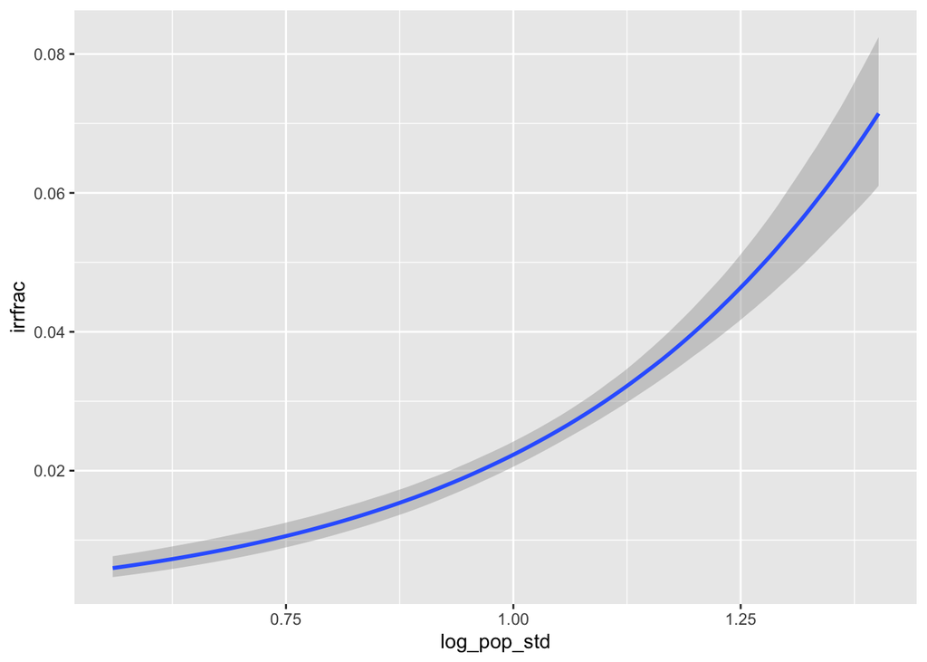

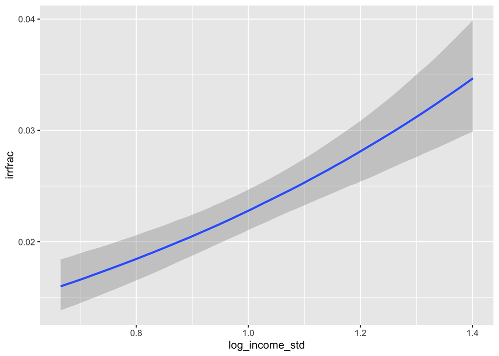

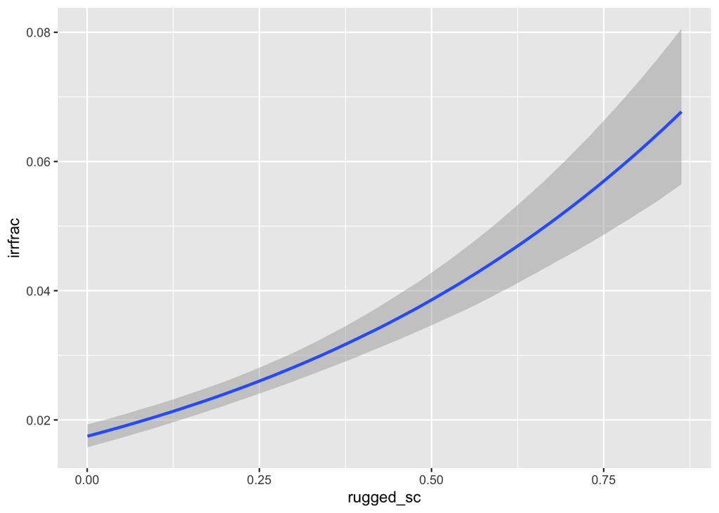

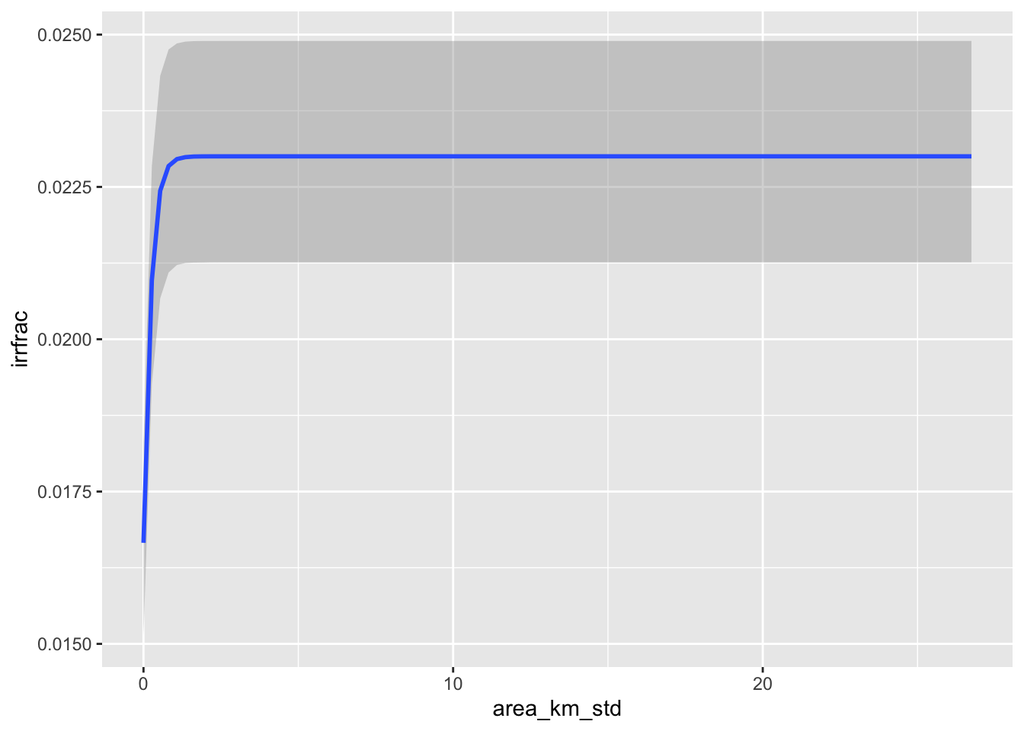

```r
conditional_effects(zi_mod_2)
```

# Its not time yet but, multilevel?

```r
zi_multi_1_bf <-
  bf(
    irrfrac ~ yearcount + log_pop_std + log_income_std + rugged_sc + (1 | four_regions ),
    zi ~ area_km_std + (1 | four_regions),
    family = zero_inflated_beta()
  )
```

```r
zi_multi_1 <-
  brm(
  formula = zi_multi_1_bf,
  data = aei,
  cores = 4,
  seed = 17,
  file = "/Volumes/RachelExternal/Thesis/Thesis/fits/CL_Zero_Inflated_Fits/zi_multi_1"
)
```

Some Divergent Transitions here

```r
print(zi_multi_1)
```

```
##  Family: zero_inflated_beta
##   Links: mu = logit; phi = identity; zi = logit
## Formula: irrfrac ~ yearcount + log_pop_std + log_income_std + rugged_sc + (1 | four_regions)
##          zi ~ area_km_std + (1 | four_regions)
##    Data: aei (Number of observations: 1440)
## Samples: 4 chains, each with iter = 2000; warmup = 1000; thin = 1;
##          total post-warmup samples = 4000
##
## Group-Level Effects:
## ~four_regions (Number of levels: 4)
##                  Estimate Est.Error l-95% CI u-95% CI Rhat Bulk_ESS Tail_ESS
## sd(Intercept)        0.78      0.47     0.30     2.13 1.07      869     1284
## sd(zi_Intercept)     2.60      2.64     0.53     9.59 1.23       14       15
##
## Population-Level Effects:
##                Estimate Est.Error l-95% CI u-95% CI Rhat Bulk_ESS Tail_ESS
## Intercept         -6.22      0.63    -7.16    -4.82 1.11       23      236
## zi_Intercept       0.51      2.53    -1.98     6.44 1.20       15       19
## yearcount          0.01      0.00     0.01     0.01 1.02      191     2771
## log_pop_std        2.61      0.21     2.18     3.01 1.02      317     2845
## log_income_std    -0.56      0.23    -1.03    -0.16 1.05       51     2442
## rugged_sc          1.08      0.14     0.80     1.36 1.08     3783     2443
## zi_area_km_std    -5.29      0.64    -6.69    -4.08 1.08     2662     1875
##
## Family Specific Parameters:
##     Estimate Est.Error l-95% CI u-95% CI Rhat Bulk_ESS Tail_ESS
## phi    24.96      1.27    22.74    27.53 1.06       48      579
##
## Samples were drawn using sampling(NUTS). For each parameter, Bulk_ESS
## and Tail_ESS are effective sample size measures, and Rhat is the potential
## scale reduction factor on split chains (at convergence, Rhat = 1).
```

Vuorre, Matti. 2019. “Sometimes I R: How to Analyze Visual Analog (Slider) Scale Data?” February. https://mvuorre.github.io/posts/2019-02-18-analyze-analog-scale-ratings-with-zero-one-inflated-beta-models/.